# Final Project

## Comments on Weibull

Looking at the residuals it looks like a weibull distribution is not a good fit for the parametric model. From here we need to figure out which distribution should be used for our survival analysis.

## Best Distribution

```r
library(muhaz)
library(survival)
library(flexsurv)
library(data.table)
```

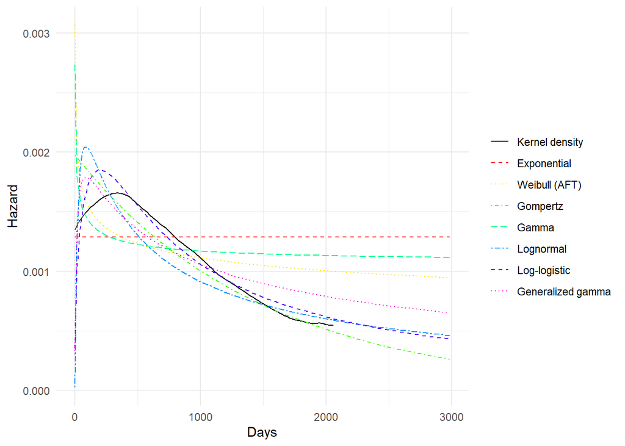

```r
library(ggplot2)
ggplot2::theme_set(theme_minimal())
kernel_haz_est <- muhaz(df$combd,df$combc)
kernel_haz <- data.table(time = kernel_haz_est$est.grid,
                         est = kernel_haz_est$haz.est,
                         method = "Kernel density")
dists <- c("exp", "weibull", "gompertz", "gamma",
           "lognormal", "llogis", "gengamma")
dists_long <- c("Exponential", "Weibull (AFT)",
                "Gompertz", "Gamma", "Lognormal", "Log-logistic",
                "Generalized gamma")
parametric_haz <- vector(mode = "list", length = length(dists))
for (i in 1:length(dists)){
  fit <- flexsurvreg(Surv(combd, combc) ~ 1, data = df, dist = dists[i])
  parametric_haz[[i]] <- summary(fit, type = "hazard",
                                     ci = FALSE, tidy = TRUE)
  parametric_haz[[i]]$method <- dists_long[i]
}
parametric_haz <- rbindlist(parametric_haz)
haz <- rbind(kernel_haz, parametric_haz)
haz[, method := factor(method,
                       levels = c("Kernel density",
                                  dists_long))]
n_dists <- length(dists)
ggplot(haz, aes(x = time, y = est, col = method, linetype = method)) +
  geom_line() +
  xlab("Days") + ylab("Hazard") +
  scale_colour_manual(name = "",
                      values = c("black", rainbow(n_dists))) +
  scale_linetype_manual(name = "",
                        values = c(1, rep_len(2:6, n_dists)))
```

## Comments on Distribution

Looking online I found a way to plot the hazard functions for each of the distributions. When looking at the graph it looks like the log logistic hazard function is the closest to our hazard function.